# EDA nightmare analysis

# Check normality assumption for SCR

```r
shapiro.test(merged$SCR)
```

```
    Shapiro-Wilk normality test

data:  merged$SCR
W = 0.18773, p-value < 2.2e-16
```

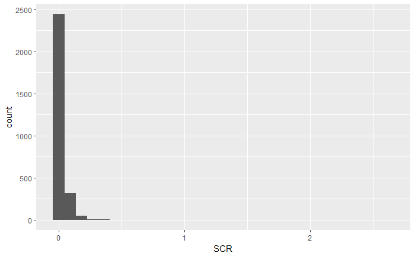

```r
ggplot(data = merged) +
        aes(SCR) +
        geom_histogram()
```

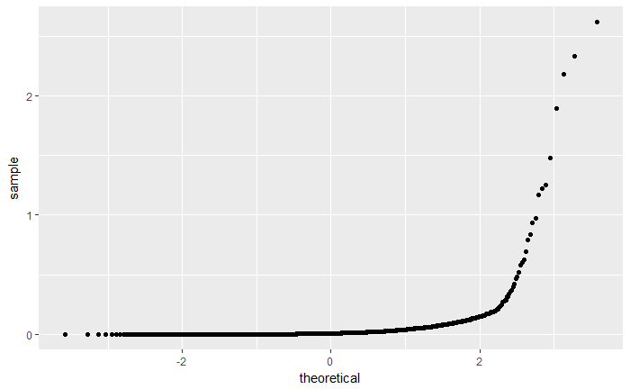

```r
ggplot(data = merged) +
        aes(sample = SCR) +
        geom_qq()
```

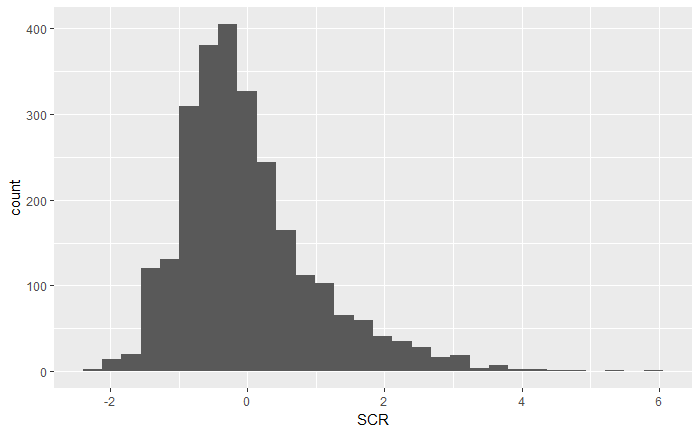

```r
merged <-
        merged %>%
        filter(!TestId %in% c("01", "05", "18", "31")) %>% # Removing excluded participants
        group_by(TestId) %>%
        mutate(SCR = SCR %>% sqrt %>% scale %>% as.numeric()) %>%
        ungroup()  %>%
        mutate(picture_set = if_else(session == "emot" & is.na(picture_set), "Original", picture_set))
# Check if it is better (yes)
ggplot(data = merged) +
        aes(SCR) +
        geom_histogram()
```

Much better this way.

# Build lmer with a top-down method

## 1. Disregard random structure to build a simple lm model

```r
nm.lm <- lm(SCR ~ group * block * category, data = merged)
summary(nm.lm)
```

```
Call:
lm(formula = SCR ~ group * block * category, data = merged)

Residuals:
    Min      1Q  Median      3Q     Max
-2.2971 -0.6495 -0.1394  0.4410  5.2451

Coefficients:
                                      Estimate Std. Error t value Pr(>|t|)
(Intercept)                           0.806759   0.147859   5.456 5.72e-08 ***
groupNightmare                       -0.089420   0.197211  -0.453  0.65031
block                                -0.297573   0.068446  -4.348 1.47e-05 ***
categoryNeutral                      -1.018119   0.206735  -4.925 9.43e-07 ***
groupNightmare:block                  0.005763   0.091195   0.063  0.94963
groupNightmare:categoryNeutral        0.369283   0.275379   1.341  0.18013
block:categoryNeutral                 0.259494   0.093849   2.765  0.00576 **
groupNightmare:block:categoryNeutral -0.033026   0.124978  -0.264  0.79162
---
Signif. codes:  0 ‘***’ 0.001 ‘**’ 0.01 ‘*’ 0.05 ‘.’ 0.1 ‘ ’ 1

Residual standard error: 0.968 on 1435 degrees of freedom
  (1173 observations deleted due to missingness)
Multiple R-squared:  0.06353,   Adjusted R-squared:  0.05896
F-statistic: 13.91 on 7 and 1435 DF,  p-value: < 2.2e-16
```

```r
AIC(nm.lm)
```

```
[1] 4011.075
```

## 2. Use full model with full random structure (random intercept and slope)

```r
nm.lmer.is <- lmer(SCR ~ group * block * category + (block|TestId), data = merged, REML = F)
nm.lmer.i <- lmer(SCR ~ group * block * category + (1|TestId), data = merged, REML = F)
AIC(nm.lmer.is) # Best AIC, but only by a small margin
```

```
[1] 3980.263
```

```r
AIC(nm.lmer.i)
```

```
[1] 3981.241
```

```r
anova(nm.lmer.is, nm.lmer.i) # Random intercept is a better model
```

```
Data: merged
Models:
..1: SCR ~ group * block * category + (1 | TestId)
object: SCR ~ group * block * category + (block | TestId)
       Df    AIC    BIC  logLik deviance  Chisq Chi Df Pr(>Chisq)
..1    10 3981.2 4034.0 -1980.6   3961.2
object 12 3980.3 4043.6 -1978.1   3956.3 4.9781      2    0.08299 .
---
Signif. codes:  0 ‘***’ 0.001 ‘**’ 0.01 ‘*’ 0.05 ‘.’ 0.1 ‘ ’ 1
```

```r
summary(nm.lmer.is)
```

```
Linear mixed model fit by maximum likelihood t-tests use Satterthwaite approximations to
  degrees of freedom [lmerMod]
Formula: SCR ~ group * block * category + (block | TestId)
   Data: merged

     AIC      BIC   logLik deviance df.resid
  3980.3   4043.6  -1978.1   3956.3     1431

Scaled residuals:
    Min      1Q  Median      3Q     Max
-2.3564 -0.6202 -0.1564  0.4515  5.7265

Random effects:
 Groups   Name        Variance Std.Dev. Corr
 TestId   (Intercept) 0.08509  0.2917
          block       0.01627  0.1276   -0.74
 Residual             0.88105  0.9386
Number of obs: 1443, groups:  TestId, 23

Fixed effects:
                                       Estimate Std. Error         df t value Pr(>|t|)
(Intercept)                           8.068e-01  1.705e-01  5.560e+01   4.732 1.57e-05 ***
groupNightmare                       -9.456e-02  2.272e-01  5.600e+01  -0.416 0.678890
block                                -2.976e-01  7.767e-02  6.070e+01  -3.831 0.000305 ***
categoryNeutral                      -1.018e+00  2.005e-01  1.397e+03  -5.080 4.28e-07 ***
groupNightmare:block                  7.443e-03  1.034e-01  6.100e+01   0.072 0.942869
groupNightmare:categoryNeutral        3.759e-01  2.670e-01  1.397e+03   1.408 0.159422
block:categoryNeutral                 2.595e-01  9.101e-02  1.397e+03   2.852 0.004412 **
groupNightmare:block:categoryNeutral -3.563e-02  1.212e-01  1.397e+03  -0.294 0.768804
---
Signif. codes:  0 ‘***’ 0.001 ‘**’ 0.01 ‘*’ 0.05 ‘.’ 0.1 ‘ ’ 1

Correlation of Fixed Effects:
            (Intr) grpNgh block  ctgryN grpNg: grpN:N blck:N
groupNghtmr -0.750
block       -0.875  0.656
categryNtrl -0.601  0.451  0.566
grpNghtmr:b  0.657 -0.875 -0.751 -0.425
grpNghtmr:N  0.452 -0.603 -0.425 -0.751  0.567
blck:ctgryN  0.568 -0.426 -0.623 -0.927  0.468  0.696
grpNghtm::N -0.426  0.569  0.468  0.696 -0.624 -0.927 -0.751
```

```r
# 3. Removing fixed terms from the model
nm.model <- nm.lmer.is # This is the structure we go forward
# 3-way interaction
nm.3I <- update(nm.model, . ~ . - group:block:category) # Remove 3way interaction
anova(nm.model, nm.3I) # Does not add to the model
```

```
Data: merged
Models:
..1: SCR ~ group + block + category + (block | TestId) + group:block +
..1:     group:category + block:category
object: SCR ~ group * block * category + (block | TestId)
       Df    AIC    BIC  logLik deviance  Chisq Chi Df Pr(>Chisq)
..1    11 3978.3 4036.4 -1978.2   3956.3
object 12 3980.3 4043.6 -1978.1   3956.3 0.0864      1     0.7688
```

```r
nm.model <- nm.3I
# 2-way interaction
nm.2I.1 <-  update(nm.model, . ~ . - group:block)
nm.2I.2 <-  update(nm.model, . ~ . - group:category)
nm.2I.3 <-  update(nm.model, . ~ . - block:category)
anova(nm.model, nm.2I.1)
```

```
Data: merged
Models:
nm.2I.1: SCR ~ group + block + category + (block | TestId) + group:category +
nm.2I.1:     block:category
nm.model: SCR ~ group + block + category + (block | TestId) + group:block +
nm.model:     group:category + block:category
         Df    AIC    BIC  logLik deviance  Chisq Chi Df Pr(>Chisq)
nm.2I.1  10 3976.4 4029.1 -1978.2   3956.4
nm.model 11 3978.3 4036.4 -1978.2   3956.3 0.0203      1     0.8866
```

```r
# group:block does not improve the model, so remove
nm.model <- nm.2I.1
# Get rid of unimportant main effects
nm.M.1 <-  update(nm.model, . ~ . - group)
nm.M.2 <-  update(nm.model, . ~ . - block)
nm.M.3 <-  update(nm.model, . ~ . - category)
anova(nm.model, nm.M.3) # No main effect should be removed
```

```
Data: merged
Models:
nm.model: SCR ~ group + block + category + (block | TestId) + group:category +
nm.model:     block:category
nm.M.3: SCR ~ group + block + (block | TestId) + group:category + block:category
         Df    AIC    BIC  logLik deviance Chisq Chi Df Pr(>Chisq)
nm.model 10 3976.4 4029.1 -1978.2   3956.4
nm.M.3   10 3976.4 4029.1 -1978.2   3956.4     0      0          1
```

## So the final model is:

```r
summary(nm.model)
```

```
Linear mixed model fit by maximum likelihood  ['lmerMod']
Formula: SCR ~ group + block + category + (block | TestId) + group:category +
    block:category
   Data: merged

     AIC      BIC   logLik deviance df.resid
  3976.4   4029.1  -1978.2   3956.4     1433

Scaled residuals:
    Min      1Q  Median      3Q     Max
-2.3488 -0.6237 -0.1547  0.4499  5.7262

Random effects:
 Groups   Name        Variance Std.Dev. Corr
 TestId   (Intercept) 0.08516  0.2918
          block       0.01630  0.1277   -0.74
 Residual             0.88111  0.9387
Number of obs: 1443, groups:  TestId, 23

Fixed effects:
                               Estimate Std. Error t value
(Intercept)                     0.79754    0.12854   6.205
groupNightmare                 -0.07813    0.10988  -0.711
block                          -0.29339    0.05131  -5.718
categoryNeutral                -0.97706    0.14387  -6.791
groupNightmare:categoryNeutral  0.30256    0.09985   3.030
block:categoryNeutral           0.23943    0.06010   3.984

Correlation of Fixed Effects:
            (Intr) grpNgh block  ctgryN grpN:N
groupNghtmr -0.481
block       -0.766 -0.002
categryNtrl -0.574  0.183  0.521
grpNghtmr:N  0.225 -0.472  0.002 -0.391
blck:ctgryN  0.498  0.002 -0.624 -0.853 -0.001
```

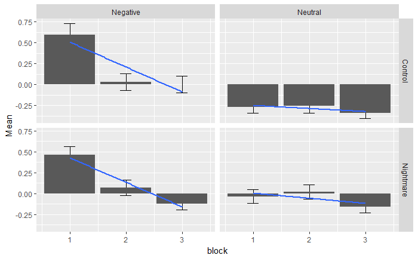

```r
merged %>%
        filter(session == "emot") %>%
        drop_na(block) %>%
        group_by(block, category, group) %>%
        summarise(Mean = mean(SCR, na.rm = T),
                  Sd = sd(SCR, na.rm = T),
                  N = n(),
                  Se = Sd/sqrt(N)) %>%
        ggplot() +
        aes(x = block, y = Mean, ymin = Mean-Se, ymax = Mean + Se) +
        geom_errorbar(width = .2) +
        geom_col(position = "dodge") +
        facet_grid(group~category, scales = "free_x") +
        geom_smooth(method = lm, se = FALSE)
```

# Conclusion

The model shows that:  
- **Checking paradigm assumptions:** There was a habituation in responses in general (block main effect), and the habituation was larger for the Negative pictures (block x category interaction). Negative pictures were associated with larger SCR in general (category main effect).  
- **Checking main hypothesis:** The initial hypothesis of the three way introduction can not be proven, so NM participants do not show slower habilitiation than non-NM for negative stimuli. In fact the habituation of NM and NNM is the quite similar.  
- **Significant effects:** There were differences though between NM and NNM groups. NM participants had a higher skin response to neutral stimuli in general compared to NNM (group x category).

# Checking the recall data

```r
## Build lmer with a top-down method
# 1. Disregard random structure
morning.lm <- lm(SCR ~ group * category * session + picture_set*group*category, data = merged)
morning.i <- lmer(SCR ~ group * category * session + picture_set*group*category + (1|TestId), data = merged)
morning.is <- lmer(SCR ~ group * category * session + picture_set*group*category + (session|TestId), data = merged) # We don't have 4-way interaction in the model
# The best model is the random intercept, random slope model
AIC(morning.lm)
```

```
[1] 6731.937
```

```r
anova(morning.i, morning.is)
```

```
refitting model(s) with ML (instead of REML)
convergence code 3 from bobyqa: bobyqa -- a trust region step failed to reduce q
```

```
Data: merged
Models:
object: SCR ~ group * category * session + picture_set * group * category +
object:     (1 | TestId)
..1: SCR ~ group * category * session + picture_set * group * category +
..1:     (session | TestId)
       Df    AIC    BIC  logLik deviance  Chisq Chi Df Pr(>Chisq)
object 14 6733.9 6815.1 -3353.0   6705.9
..1    16 6602.5 6695.2 -3285.2   6570.5 135.45      2  < 2.2e-16 ***
---
Signif. codes:  0 ‘***’ 0.001 ‘**’ 0.01 ‘*’ 0.05 ‘.’ 0.1 ‘ ’ 1
```

```r
morning.model <- morning.is
summary(morning.model)
```

```
Linear mixed model fit by REML t-tests use Satterthwaite approximations to degrees of freedom [
lmerMod]
Formula: SCR ~ group * category * session + picture_set * group * category +
    (session | TestId)
   Data: merged

REML criterion at convergence: 6607.5

Scaled residuals:
    Min      1Q  Median      3Q     Max
-2.4834 -0.6253 -0.1567  0.4080  5.8702

Random effects:
 Groups   Name          Variance Std.Dev. Corr
 TestId   (Intercept)   0.05324  0.2307
          sessionrecall 0.31924  0.5650   -1.00
 Residual               0.86353  0.9293
Number of obs: 2426, groups:  TestId, 23

Fixed effects:
                                                     Estimate Std. Error         df t value
(Intercept)                                           0.36995    0.15988  292.80000   2.314
groupNightmare                                       -0.17348    0.21268  292.90000  -0.816
categoryNeutral                                      -0.74794    0.19584 2393.00000  -3.819
sessionrecall                                        -0.10595    0.20863   31.80000  -0.508
picture_setOriginal                                  -0.15834    0.13175 2393.00000  -1.202
groupNightmare:categoryNeutral                        0.38177    0.26019 2393.00000   1.467
groupNightmare:sessionrecall                         -0.05820    0.27752   31.80000  -0.210
categoryNeutral:sessionrecall                         0.27579    0.14520 2393.10000   1.899
groupNightmare:picture_setOriginal                    0.09189    0.17520 2393.00000   0.524
categoryNeutral:picture_setOriginal                   0.24500    0.18125 2393.00000   1.352
groupNightmare:categoryNeutral:sessionrecall         -0.16162    0.19273 2393.00000  -0.839
groupNightmare:categoryNeutral:picture_setOriginal   -0.07707    0.24071 2393.00000  -0.320
                                                   Pr(>|t|)
(Intercept)                                        0.021363 *
groupNightmare                                     0.415332
categoryNeutral                                    0.000137 ***
sessionrecall                                      0.615078
picture_setOriginal                                0.229568
groupNightmare:categoryNeutral                     0.142437
groupNightmare:sessionrecall                       0.835225
categoryNeutral:sessionrecall                      0.057642 .
groupNightmare:picture_setOriginal                 0.600005
categoryNeutral:picture_setOriginal                0.176593
groupNightmare:categoryNeutral:sessionrecall       0.401787
groupNightmare:categoryNeutral:picture_setOriginal 0.748855
---
Signif. codes:  0 ‘***’ 0.001 ‘**’ 0.01 ‘*’ 0.05 ‘.’ 0.1 ‘ ’ 1

Correlation of Fixed Effects:
            (Intr) grpNgh ctgryN sssnrc pctr_O grpN:N grpNg: ctgrN: grN:_O ctN:_O grN:N:
groupNghtmr -0.752
categryNtrl -0.646  0.486
sessionrcll -0.739  0.555  0.284
pctr_stOrgn -0.824  0.620  0.673  0.317
grpNghtmr:N  0.486 -0.647 -0.753 -0.214 -0.506
grpNghtmr:s  0.555 -0.739 -0.213 -0.752 -0.239  0.284
ctgryNtrl:s  0.500 -0.376 -0.741 -0.383 -0.456  0.558  0.288
grpNghtm:_O  0.620 -0.824 -0.506 -0.239 -0.752  0.673  0.317  0.343
ctgryNtr:_O  0.599 -0.450 -0.925 -0.231 -0.727  0.697  0.173  0.592  0.547
grpNghtm:N: -0.376  0.501  0.559  0.288  0.343 -0.741 -0.384 -0.753 -0.457 -0.446
grpNgh:N:_O -0.451  0.600  0.697  0.174  0.547 -0.925 -0.231 -0.446 -0.728 -0.753  0.590
```

```r
## Removing interacions
# Checking 3-way interactions
morning.3I.1 <- update(morning.model, . ~ . - group:session:category) # Drop
morning.3I.2 <- update(morning.model, . ~ . - group:picture_set:category) # Drop
anova(morning.model, morning.3I.1, morning.3I.2)
```

```
refitting model(s) with ML (instead of REML)
```

```
Data: merged
Models:
morning.3I.1: SCR ~ group + category + (session | TestId) + group:category +
morning.3I.1:     group:category:picture_set
morning.3I.2: SCR ~ group + category + (session | TestId) + group:category +
morning.3I.2:     group:category:session
morning.model: SCR ~ group + category + (session | TestId) + group:category +
morning.model:     group:category:session + group:category:picture_set
              Df    AIC    BIC  logLik deviance  Chisq Chi Df Pr(>Chisq)
morning.3I.1  12 6599.4 6668.9 -3287.7   6575.4
morning.3I.2  12 6597.6 6667.2 -3286.8   6573.6 1.7329      0     <2e-16 ***
morning.model 16 6602.5 6695.2 -3285.2   6570.5 3.1485      4     0.5333
---
Signif. codes:  0 ‘***’ 0.001 ‘**’ 0.01 ‘*’ 0.05 ‘.’ 0.1 ‘ ’ 1
```

```r
morning.model <- update(morning.model, . ~ . -group:session:category -group:picture_set:category )
```

```r
# Checking 2-way interactions
morning.2I.1 <- update(morning.model, . ~ . - group:session) # Drop
morning.2I.2 <- update(morning.model, . ~ . - picture_set:category) # Drop
morning.2I.3 <- update(morning.model, . ~ . - group:category) # Do not drop
morning.2I.4 <- update(morning.model, . ~ . - group:picture_set) # Drop
morning.2I.5 <- update(morning.model, . ~ . - session:category) # Drop
morning.model <- update(morning.model, . ~ . - group:session - group:picture_set - picture_set:category - session:category)
morning.model %>% summary
```

```
Linear mixed model fit by REML ['lmerMod']
Formula: SCR ~ group + category + (session | TestId) + group:category
   Data: merged

REML criterion at convergence: 6595

Scaled residuals:
    Min      1Q  Median      3Q     Max
-2.4714 -0.6233 -0.1650  0.4204  5.9069

Random effects:
 Groups   Name          Variance Std.Dev. Corr
 TestId   (Intercept)   0.04954  0.2226
          sessionrecall 0.29745  0.5454   -1.00
 Residual               0.86319  0.9291
Number of obs: 2426, groups:  TestId, 23

Fixed effects:
                               Estimate Std. Error t value
(Intercept)                     0.20157    0.04160   4.846
groupNightmare                 -0.12472    0.05540  -2.251
categoryNeutral                -0.43930    0.05732  -7.664
groupNightmare:categoryNeutral  0.25584    0.07623   3.356

Correlation of Fixed Effects:
            (Intr) grpNgh ctgryN
groupNghtmr -0.751
categryNtrl -0.726  0.545
grpNghtmr:N  0.546 -0.727 -0.752
```

```r
# Checking main effects
morning.M.1 <- update(morning.model, . ~ . - group)
morning.M.2 <- update(morning.model, . ~ . - session) # Dop
morning.M.3 <- update(morning.model, . ~ . - picture_set) # Drop
morning.M.4 <- update(morning.model, . ~ . - category)
anova(morning.model, morning.M.1, morning.M.2, morning.M.3, morning.M.4)
```

```
refitting model(s) with ML (instead of REML)
```

```
Data: merged
Models:
morning.model: SCR ~ group + category + (session | TestId) + group:category
morning.M.1: SCR ~ category + (session | TestId) + group:category
morning.M.2: SCR ~ group + category + (session | TestId) + group:category
morning.M.3: SCR ~ group + category + (session | TestId) + group:category
morning.M.4: SCR ~ group + (session | TestId) + group:category
              Df    AIC    BIC  logLik deviance Chisq Chi Df Pr(>Chisq)
morning.model  8 6592.2 6638.5 -3288.1   6576.2
morning.M.1    8 6592.2 6638.5 -3288.1   6576.2     0      0          1
morning.M.2    8 6592.2 6638.5 -3288.1   6576.2     0      0     <2e-16 ***
morning.M.3    8 6592.2 6638.5 -3288.1   6576.2     0      0          1
morning.M.4    8 6592.2 6638.5 -3288.1   6576.2     0      0     <2e-16 ***
---
Signif. codes:  0 ‘***’ 0.001 ‘**’ 0.01 ‘*’ 0.05 ‘.’ 0.1 ‘ ’ 1
```

```r
morning.model <- update(morning.model, .~. - session -picture_set)
```

```r
# Final model
morning.model %>% summary
```

```
Linear mixed model fit by REML ['lmerMod']
Formula: SCR ~ group + category + (session | TestId) + group:category
   Data: merged

REML criterion at convergence: 6595

Scaled residuals:
    Min      1Q  Median      3Q     Max
-2.4714 -0.6233 -0.1650  0.4204  5.9069

Random effects:
 Groups   Name          Variance Std.Dev. Corr
 TestId   (Intercept)   0.04954  0.2226
          sessionrecall 0.29745  0.5454   -1.00
 Residual               0.86319  0.9291
Number of obs: 2426, groups:  TestId, 23

Fixed effects:
                               Estimate Std. Error t value
(Intercept)                     0.20157    0.04160   4.846
groupNightmare                 -0.12472    0.05540  -2.251
categoryNeutral                -0.43930    0.05732  -7.664
groupNightmare:categoryNeutral  0.25584    0.07623   3.356

Correlation of Fixed Effects:
            (Intr) grpNgh ctgryN
groupNghtmr -0.751
categryNtrl -0.726  0.545
grpNghtmr:N  0.546 -0.727 -0.752
```

[figure not shown]

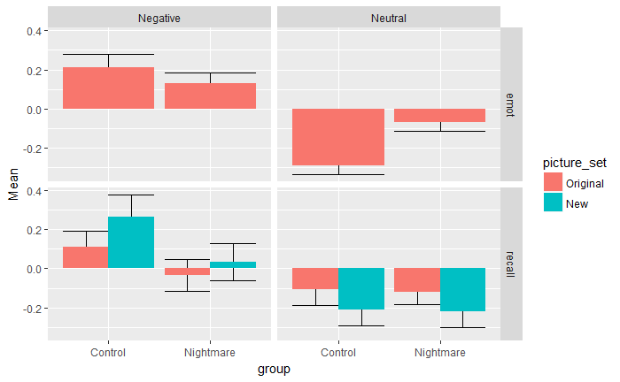

```r
merged %>%
        drop_na(picture_set, category) %>%
        mutate(picture_set = picture_set %>% factor(levels = c("Original", "New")),
        ) %>%
        group_by(picture_set, session, category, group) %>%
        summarise(Mean = mean(SCR, na.rm = T),
                  Sd = sd(SCR, na.rm = T),
                  N = n(),
                  Se = Sd/sqrt(N)) %>%
        ggplot() +
        aes(x = group, y = Mean, ymin = Mean-Se, ymax = Mean + Se, fill = picture_set, group = picture_set) +
        geom_errorbar(position = position_dodge()) +
        geom_col(position = position_dodge()) +
        facet_grid(session ~ category)
```

# Conclusion

The model yields that:

- Negative pictures elicit larger SCR response than neutral (category main effect).
- The nightmare group showed a smaller SCR reaction to negative pictures, but they also gave a larger SCR response to neutral pictures (group x category interaction)